# **Programming Demo**

For someone who never completely learned any one computer language, it sure seems like I’ve written a lot of code in my life. I remember bits of Basic, Java, Python, EasyLanguage, Stata, and some assembly language too. Recently I’ve focused on R.

For illustration, I built this HTML document using R Markdown from within R Studio. This is a solid workflow for statistical reporting and other tasks. Dynamic R code right in the document is useful.

### **1. Examine the *cars* data set that is built into R**

Here is a code block followed by an output block:

```r
str(cars) # this asks r to display the data's structure
```

```
## 'data.frame':    50 obs. of  2 variables:
##  $ speed: num  4 4 7 7 8 9 10 10 10 11 ...
##  $ dist : num  2 10 4 22 16 10 18 26 34 17 ...
```

With R Markdown we can explain as we go. Now let’s look at the distribution of the *speed* and *dist* variables. Again, see the code and then the output:

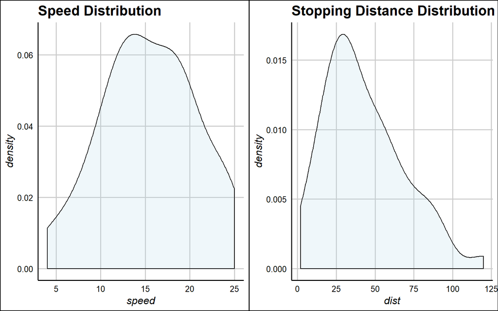

```r
ggplot(cars) + geom_density(aes(x=speed), fill="lightblue", alpha=.2) + labs(title="Speed Distribution") + theme_gdocs() -> gs

ggplot(cars) + geom_density(aes(x=dist), fill="lightblue", alpha=.2) + labs(title="Stopping Distance Distribution") + theme_gdocs() -> gd

grid.arrange(gs, gd, ncol=2)
```

### **2. Now fit a linear model on *speed* and *dist* using R’s lm() function**

This will give an idea of how the speed of the car affects stopping distance:

```r
mymod <- lm(cars$dist ~ cars$speed)
summary(mymod)
```

```
##
## Call:
## lm(formula = cars$dist ~ cars$speed)
##
## Residuals:
##     Min      1Q  Median      3Q     Max
## -29.069  -9.525  -2.272   9.215  43.201
##
## Coefficients:
##             Estimate Std. Error t value Pr(>|t|)
## (Intercept) -17.5791     6.7584  -2.601   0.0123 *
## cars$speed    3.9324     0.4155   9.464 1.49e-12 ***
## ---
## Signif. codes:  0 '***' 0.001 '**' 0.01 '*' 0.05 '.' 0.1 ' ' 1
##
## Residual standard error: 15.38 on 48 degrees of freedom
## Multiple R-squared:  0.6511, Adjusted R-squared:  0.6438
## F-statistic: 89.57 on 1 and 48 DF,  p-value: 1.49e-12
```

> The output above indicates the relationship can be described with this factor:  
> **3.9324**  
> Now instead of using R’s lm() function, I’ll go through the model with manual matrix operations.

### **3. Try fitting the same model from scratch with linear algebra**

```r
Y <- as.matrix(cars$dist) # dependent in Y
X <- as.matrix(cars$speed) # one independent in X
colnames(X) <- c("speed")
X <- cbind(x0=1, X) # add a buncha ones to matrix X
b <- solve(t(X) %*% X) %*% t(X) %*% Y # ols matrix solution
b
```

```
##             [,1]
## x0    -17.579095
## speed   3.932409
```

> We got the same coefficient:  
> **3.9324**  
> Pretty cool!

### **4. Next manually find the standard errors**

```r
# H <- X %*% solve(t(X) %*% X) %*% t(X) # hat matrix
# Yhat <- H %*% Y # predictions

Yhat <- X %*% solve(t(X) %*% X) %*% t(X) %*% Y # predictions
R <- Y - Yhat # residual errors
MSE <- sum(R^2) / (nrow(X) - ncol(X) + 1 -1) # df = n - m

# added ones to matrix X so ??? add 1 df back in
# ncol(x) doesn't include Y so ??? subtract an extra 1 df

var_bhat <- MSE * (solve(t(X) %*% X)) # variance
SE <- sqrt(diag(var_bhat)) # extract standard errors
SE
```

```
##        x0     speed
## 6.7584402 0.4155128
```

> This SE vector exactly matches the lm() results.  
> The SE on speed is:  
> **.4155**

### **5. Fit with ‘estimatr’ package, and HC1 robust standard errors to replicate STATA’s r switch**

```r
myrobustmod <- lm_robust(cars$dist ~ cars$speed, se_type = "stata")
summary(myrobustmod)
```

```
##
## Call:
## lm_robust(formula = cars$dist ~ cars$speed, se_type = "stata")
##
## Standard error type:  HC1
##
## Coefficients:
##             Estimate Std. Error  Pr(>|t|) CI Lower CI Upper DF
## (Intercept)  -17.579     5.6561 3.163e-03  -28.952   -6.207 48
## cars$speed     3.932     0.4069 7.654e-13    3.114    4.751 48
##
## Multiple R-squared:  0.6511 ,    Adjusted R-squared:  0.6438
## F-statistic:  93.4 on 1 and 48 DF,  p-value: 7.654e-13
```

> SE on speed is:  
> **.4069**  
> While SE from the lm() model was:  
> **.4155**  
> Robust SE is one way to handle heteroscedasticity.

### **6. Should a linear model even be used here?**

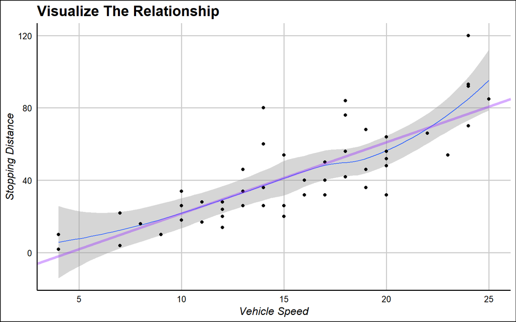

```r
ggplot(cars, aes(x=speed, y=dist)) + geom_smooth(size=.5) + geom_point() + geom_abline(intercept=-17.579, slope=3.9324, color="purple1", size=1.5, alpha=.4) + labs(x="Vehicle Speed", y="Stopping Distance", title="Visualize The Relationship") + theme_gdocs()
```

Excellent! Our linear model looks like a good starting point.

### **7. R Markdown streamlines many publishing tasks. Here are two more examples.**

Equations can be inserted:

$$\sqrt{\bar{x}}=\bigg(\frac{\sum x}{n}\bigg)^.5$$

I can even include an image fetched from brettwag.com:

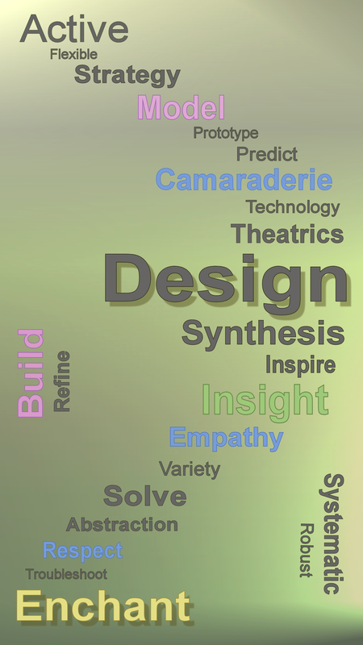

### **8. You may also be interested in “Empirical Research on Data Breach Events” under [DATA ANALYSIS](http://brettwag.com/data-analysis.html) at my website. The study features a panel regression done with R.**